# risk_plot

Abigail Tyrell

12 Feb 2021

# Risk ranking of Northeast stocks

## Methods

### Risk ranking

All stocks were ranked in order of increasing risk. The stock with the highest ranking is the stock determined to be at the highest risk. In this case, high risk has two meanings: (1) high importance (e.g., a stock with a high catch would have a high risk ranking for the catch indicator) or high vulnerability (e.g., a stock with low B/Bmsy would have a high risk ranking for the B/Bmsy indicator). The normalized rank was determined by dividing each stock’s rank by the total number of stocks considered for that indicator. Stocks that were missing indicator measurements were assigned a normalized rank of 0.5.

| Category | Indicator | Data_source | Metric | Risk |
| --- | --- | --- | --- | --- |
| Biological | avg_length_fall | survdat | Percent absolute change between the mean of the past 10 years and the historical mean | Large change is risky |
| Biological | avg_length_spring | survdat | Percent absolute change between the mean of the past 10 years and the historical mean | Large change is risky |
| Biological | max_length_fall | survdat | Percent absolute change between the mean of the past 10 years and the historical mean | Large change is risky |
| Biological | max_length_spring | survdat | Percent absolute change between the mean of the past 10 years and the historical mean | Large change is risky |
| Biological | diet | survdat (pull with bio data) | Number of prey categories from all time | Low is risky |
| Habitat | habitat_vulnerability | ecodata::habitat_vulnerability | ecodata habitat vulnerability | High is risky |
| Population | bbmsy | assessmentdata::stockAssessmentSummary | Most recent value | Low is risky |
| Population | recruitment | assessmentdata::stockAssessmentData | Percent absolute change between the mean of the past 10 years and the historical mean | Large change is risky |
| Population | asmt_abundance | assessmentdata::stockAssessmentData | Percent absolute change between the mean of the past 10 years and the historical mean | Large change is risky |
| Population | asmt_biomass | assessmentdata::stockAssessmentData | Percent absolute change between the mean of the past 10 years and the historical mean | Large change is risky |

[output cut: 14 more lines]

### Guilds

Guilds were determined from [previous reporting](https://repository.library.noaa.gov/view/noaa/5277). Guilds were further broken into small (<40cm) and large (>=40cm) size classes. To determine guild risk, the risk values for each species were averaged over all stock areas. Then risk values were averaged by guild. Guilds were ranked in each indicator category.

| Guild | Size | Species | Scientific_name |
| --- | --- | --- | --- |
|  | small | Bluefish | Pomatomus saltatrix |
| demersal_benthivore | large | Atlantic wolffish | Anarhichas lupus |
| demersal_benthivore | large | Clearnose skate | Raja eglanteria |
| demersal_benthivore | large | Ocean pout | Zoarces americanus |
| demersal_benthivore | large | Smooth skate | Malacoraja senta |
| demersal_benthivore | small | Acadian redfish | Sebastes fasciatus |
| demersal_benthivore | small | American plaice | Hippoglossoides platessoides |
| demersal_benthivore | small | Haddock | Melanogrammus aeglefinus |
| demersal_benthivore | small | Red hake | Urophycis chuss |
| demersal_benthivore | small | Rosette skate | Leucoraja garmani |

[output cut: 27 more lines]

## Results

### Stock risk

Ranks for all stocks.

#### Figures

The number following the species name is the total risk (sum of all normalized risk values).

| Abbreviation | Region |
| --- | --- |
| CC | Cape Cod |
| GOM | Gulf of Maine |
| GB | Georges Bank |
| NE | New England |
| Mid | Mid-Atlantic |
| E | East |
| N | North |
| S | South |

##### By region

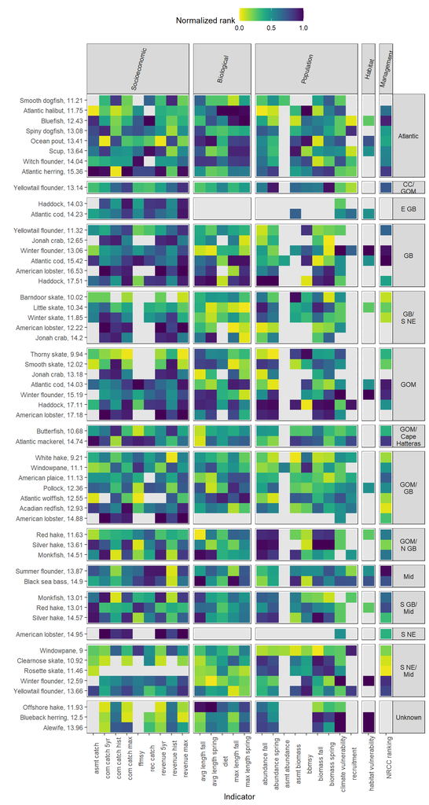

##### In order of risk

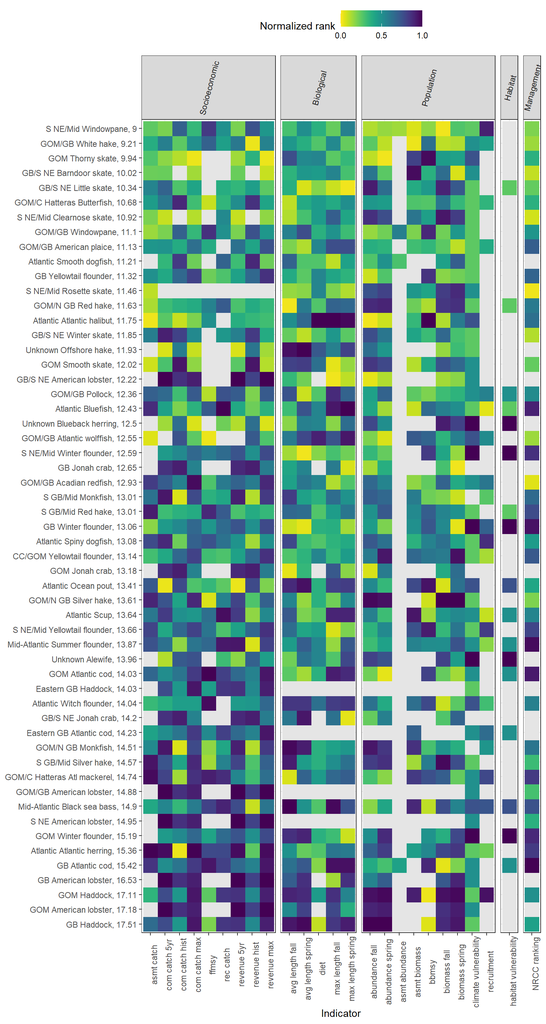

#### Data

##### All data

| Species | Region | Indicator | category | Year | Value | rank | n_stocks_per_indicator | norm_rank | total_risk | overall_rank | overall_stocks |
| --- | --- | --- | --- | --- | --- | --- | --- | --- | --- | --- | --- |
| Acadian redfish | Gulf of Maine / Georges Bank | bbmsy | Population | 2017 | 1.45 | 10 | 41 | 0.244 | 12.93 | 25 | 55 |
| Acadian redfish | Gulf of Maine / Georges Bank | ffmsy | Socioeconomic | 2017 | 0.28 | 10 | 36 | 0.278 | 12.93 | 25 | 55 |
| Acadian redfish | Gulf of Maine / Georges Bank | asmt_catch | Socioeconomic | 1942 | 55,892.00 | 33 | 40 | 0.825 | 12.93 | 25 | 55 |
| Acadian redfish | Gulf of Maine / Georges Bank | recruitment | Population | mean of 2009 - 2019 | 0.68 | 14 | 23 | 0.609 | 12.93 | 25 | 55 |
| Acadian redfish | Gulf of Maine / Georges Bank | asmt_abundance | Population |  | NA |  |  |  | 12.93 | 25 | 55 |
| Acadian redfish | Gulf of Maine / Georges Bank | asmt_biomass | Population | mean of 2009 - 2019 | 0.14 | 6 | 36 | 0.167 | 12.93 | 25 | 55 |
| Acadian redfish | Gulf of Maine / Georges Bank | biomass_fall | Population | mean of 2009 - 2019 | 1.14 | 35 | 51 | 0.686 | 12.93 | 25 | 55 |
| Acadian redfish | Gulf of Maine / Georges Bank | biomass_spring | Population | magnitude of % change, magnitude of % change, mean of 2009 - 2019 vs historic vs historic | 0.39 | 20 | 51 | 0.392 | 12.93 | 25 | 55 |
| Acadian redfish | Gulf of Maine / Georges Bank | abundance_fall | Population | mean of 2009 - 2019 | 1.53 | 34 | 51 | 0.667 | 12.93 | 25 | 55 |
| Acadian redfish | Gulf of Maine / Georges Bank | abundance_spring | Population | magnitude of % change, magnitude of % change, mean of 2009 - 2019 vs historic vs historic | 0.73 | 28 | 51 | 0.549 | 12.93 | 25 | 55 |

[output cut: 1365 more lines]

##### Total risk only

| Species | Region | total_risk | overall_rank |
| --- | --- | --- | --- |
| Acadian redfish | Gulf of Maine / Georges Bank | 12.93 | 25 |
| American plaice | Gulf of Maine / Georges Bank | 11.13 | 9 |
| Atlantic cod | Georges Bank | 15.42 | 51 |
| Atlantic cod | Gulf of Maine | 14.03 | 38 |
| Atlantic halibut | Atlantic | 11.75 | 14 |
| Atlantic herring | Atlantic | 15.36 | 50 |
| Atlantic mackerel | Gulf of Maine / Cape Hatteras | 14.74 | 45 |
| Atlantic wolffish | Gulf of Maine / Georges Bank | 12.55 | 22 |
| Barndoor skate | Georges Bank / Southern New England | 10.02 | 4 |
| Black sea bass | Mid-Atlantic | 14.9 | 47 |

[output cut: 45 more lines]

### Guild risk

#### Figure

The number following the guild name is the total risk (sum of all average normalized risk values).

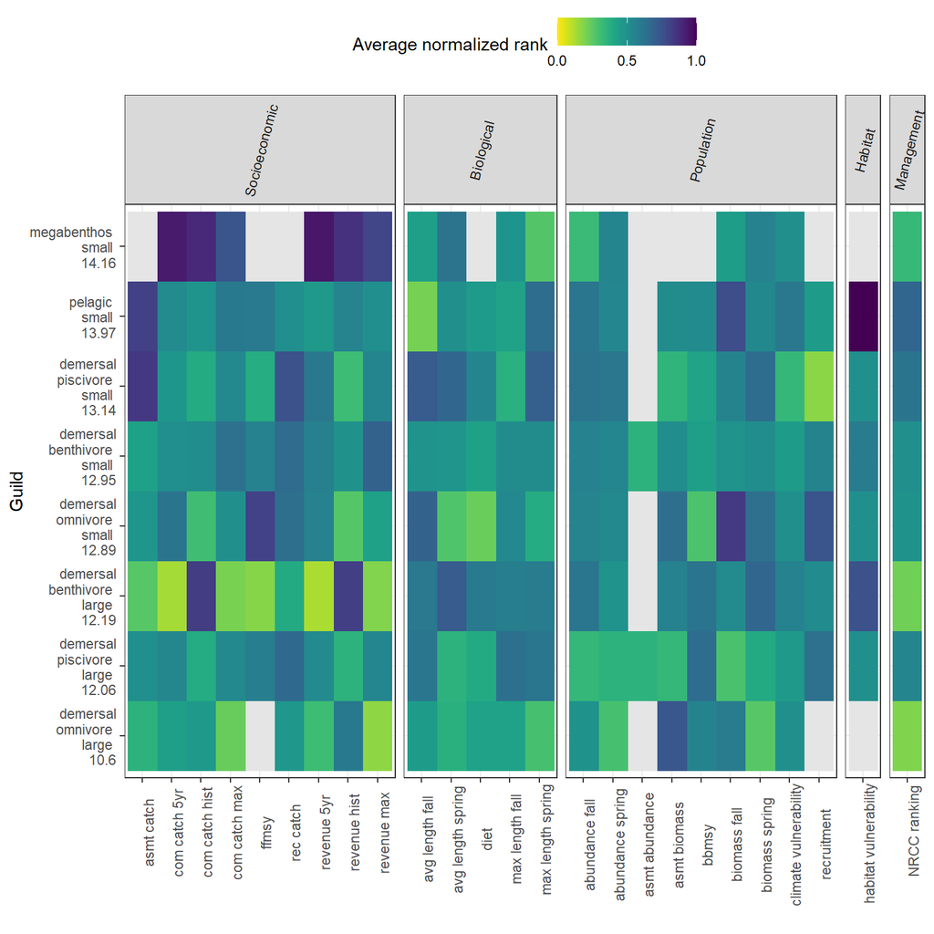

#### Data

| Guild | n_guild_species | category | Indicator | avg_guild_risk | total_guild_risk |
| --- | --- | --- | --- | --- | --- |
| demersal_benthivore large | 4 | Biological | avg_length_fall | 0.60 | 12.19 |
| demersal_benthivore small | 10 | Biological | avg_length_fall | 0.48 | 12.95 |
| demersal_omnivore large | 3 | Biological | avg_length_fall | 0.45 | 10.6 |
| demersal_omnivore small | 2 | Biological | avg_length_fall | 0.69 | 12.89 |
| demersal_piscivore large | 6 | Biological | avg_length_fall | 0.61 | 12.06 |
| demersal_piscivore small | 3 | Biological | avg_length_fall | 0.72 | 13.14 |
| megabenthos small | 2 | Biological | avg_length_fall | 0.44 | 14.16 |
| pelagic small | 5 | Biological | avg_length_fall | 0.21 | 13.97 |
| demersal_benthivore large | 4 | Biological | avg_length_spring | 0.72 | 12.19 |
| demersal_benthivore small | 10 | Biological | avg_length_spring | 0.48 | 12.95 |

[output cut: 190 more lines]